# Sentiment_analysis_taskforce

Frederik Normann Holm

2023-01-10

## Loading packages

For the sentiment analysis i will need the following packages as well as the NRC and AFINN lexica For text mining, pdftools, tidytext, textdata and ggwordcloud are beneficial

```r
knitr::opts_chunk$set(echo = TRUE,
                      warning = FALSE,
                      message = FALSE)

library(tidyverse)
library(here)
library(pdftools)
```

```r
library(tidytext)
library(textdata)
library(ggwordcloud)
```

## Getting the statements

For the sentiment analysis, a collection of statements by the May 4th Task Force and regular students have been collected from https://studentsonmay4.com/ They have been manually bundled together and converted into a pdf-format

```r
stat_path <- here("data","Student_statements.pdf")
stat_text <- pdf_text(stat_path)
```

## Wrangling

In the following chunk of code i split up pages into separate lines (separated by `\n`). I do this by using `stringr::str_split()` Then, i unnest into regular columns using `tidyr::unnest()`, and lastly, `stringr::str_trim()` will remove/trim starting and trailing spaces

```r
stat_df <- data.frame(stat_text) %>%
  mutate(text_full = str_split(stat_text, pattern = '\\n')) %>%
  unnest(text_full) %>%
  mutate(text_full = str_trim(text_full))
```

At this point, each line is its own row with starting and trailing spaces removed

## Getting individual words (tokens)

Here i use `tidytext::unnest_tokens()` to split columms into tokens. In this case, words are the tokens i am after

```r
stat_tokens <- stat_df %>%
  unnest_tokens(word, text_full)
stat_tokens
```

```
## # A tibble: 9,510 × 2
##    stat_text                                                               word
##    <chr>                                                                   <chr>
##  1 "1\n\n\nMy mother took me to the May 4 Museum, on Kent State’s campus,… 1
##  2 "1\n\n\nMy mother took me to the May 4 Museum, on Kent State’s campus,… my
##  3 "1\n\n\nMy mother took me to the May 4 Museum, on Kent State’s campus,… moth…
##  4 "1\n\n\nMy mother took me to the May 4 Museum, on Kent State’s campus,… took
##  5 "1\n\n\nMy mother took me to the May 4 Museum, on Kent State’s campus,… me
##  6 "1\n\n\nMy mother took me to the May 4 Museum, on Kent State’s campus,… to
##  7 "1\n\n\nMy mother took me to the May 4 Museum, on Kent State’s campus,… the
##  8 "1\n\n\nMy mother took me to the May 4 Museum, on Kent State’s campus,… may
##  9 "1\n\n\nMy mother took me to the May 4 Museum, on Kent State’s campus,… 4
## 10 "1\n\n\nMy mother took me to the May 4 Museum, on Kent State’s campus,… muse…
## # … with 9,500 more rows
```

Now i will count the words in order to see the abundance of stop words to be removed later

```r
stat_wc <- stat_tokens %>%
  count(word) %>%
  arrange(-n)
stat_wc
```

```
## # A tibble: 2,059 × 2
##    word      n
##    <chr> <int>
##  1 the     609
##  2 to      302
##  3 and     288
##  4 i       255
##  5 of      236
##  6 in      160
##  7 a       158
##  8 that    136
##  9 it      110
## 10 on      103
## # … with 2,049 more rows
```

As the count above shows, there is an abundance of stopwords. Those will be removed in the following section

## Removing stop words

by utilizng `anti_join()` from tidyr, i will remove stop words from the text

```r
stat_stop <- stat_tokens %>%
  anti_join(stop_words) %>%
  select(-stat_text)

# counting again after stopwords removed
stat_swc <- stat_stop %>%
  count(word) %>%
  arrange(-n)
stat_swc
```

```
## # A tibble: 1,669 × 2
##    word         n
##    <chr>    <int>
##  1 students    66
##  2 4th         47
##  3 people      44
##  4 kent        42
##  5 campus      32
##  6 4           25
##  7 day         23
##  8 force       22
##  9 task        22
## 10 time        21
## # … with 1,659 more rows
```

Now for removing numerics:

```r
stat_no_numeric <- stat_stop %>%
  filter(is.na(as.numeric(word)))
stat_no_numeric
```

```
## # A tibble: 3,514 × 1
##    word
##    <chr>
##  1 mother
##  2 museum
##  3 kent
##  4 state’s
##  5 campus
##  6 student
##  7 history
##  8 feel
##  9 connected
## 10 can’t
## # … with 3,504 more rows
```

Checking the amount of unique words in text data after removing stop words and numerics:

```r
length(unique(stat_no_numeric$word))
```

```
## [1] 1637
```

visualizing the 1637 unique words in a wordcloud will give a overwhelming result, so i go with the 50 most frequent words

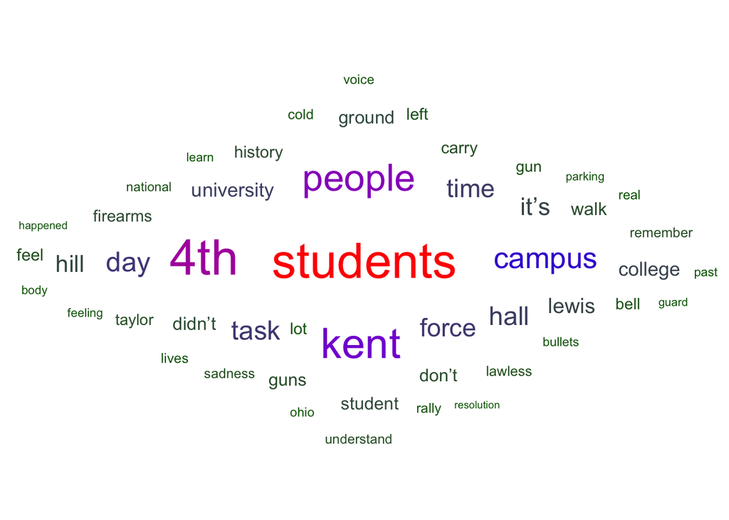

```r
stat_top50 <- stat_no_numeric %>%
  count(word) %>%
  arrange(-n) %>%
  head(50)

ggplot(data = stat_top50, aes(label = word, size = n)) +
  geom_text_wordcloud_area(aes(color = n), shape = "diamond") +
  scale_size_area(max_size = 12) +
  scale_color_gradientn(colors = c("darkgreen","blue","red")) +
  theme_minimal()
```

## Sentiment analysis NRC Now for the sentiment analysis using the NRC lexicon Firstly i load the lexicon

```r
get_sentiments(lexicon = "nrc")
```

```
## # A tibble: 13,872 × 2
##    word        sentiment
##    <chr>       <chr>
##  1 abacus      trust
##  2 abandon     fear
##  3 abandon     negative
##  4 abandon     sadness
##  5 abandoned   anger
##  6 abandoned   fear
##  7 abandoned   negative
##  8 abandoned   sadness
##  9 abandonment anger
## 10 abandonment fear
## # … with 13,862 more rows
```

Now i can start “binning” individual words to the feeling they are typically associated with

```r
stat_nrc <- stat_stop %>%
  inner_join(get_sentiments("nrc"))

#this excludes some of the words in the provided text, so i check which words have been excluded by 'anti_join()'

stat_exclude <- stat_stop %>%
  anti_join(get_sentiments("nrc"))

#counting most excluded words

stat_exclude_n <- stat_exclude %>%
  count(word, sort = TRUE)
head(stat_exclude_n)
```

```
## # A tibble: 6 × 2
##   word         n
##   <chr>    <int>
## 1 students    66
## 2 4th         47
## 3 people      44
## 4 kent        42
## 5 campus      32
## 6 4           25
```

From the list of excluded words, it can be said that none of them have an influence on the overall outcome of the sentiment analysis

Now i count and plot the amount of words in each sentiment category in order to gain an overview of overall sentiments

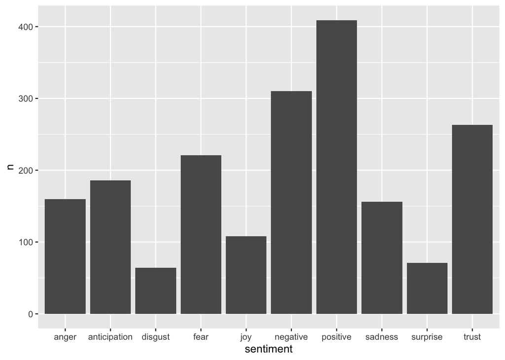

```r
stat_nrc_n <- stat_nrc %>%
  count(sentiment, sort = TRUE)
  ggplot(data = stat_nrc_n, aes(x = sentiment, y = n)) +
  geom_col()
```

Now for a more detailed visualization of all the sentiment categories and the top words associated with each of them:

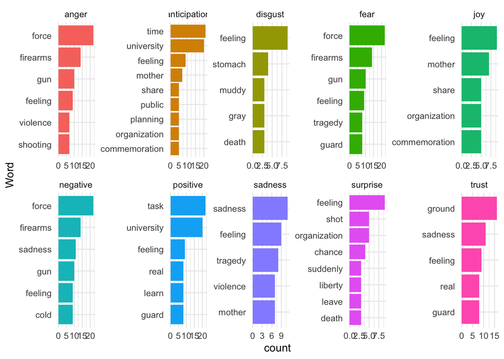

```r
#first i count and group the words with a minimum of 5 appearances for each sentiment category
stat_nrc_n5 <- stat_nrc %>%
  count(word,sentiment, sort = TRUE) %>%
  group_by(sentiment) %>%
  top_n(5) %>%
  ungroup()
#then i add the top words for each sentiment to a ggplot
stat_nrc_gg <- ggplot(data = stat_nrc_n5, aes(x = reorder(word,n), y = n, fill = sentiment)) +
  geom_col(show.legend = FALSE) +
  facet_wrap(~sentiment, ncol = 5, scales = "free") +
  coord_flip() +
  theme_minimal() +
  labs(x = "Word", y = "count")
stat_nrc_gg
```

In the context of the Kent State Shootings, the fact that “guard” is included under “trust” and “positive” is counterintuitive for the goal of the report so i check the word “guard”

```r
guard <- get_sentiments(lexicon = "nrc") %>%
  filter(word == "guard")
guard
```

```
## # A tibble: 3 × 2
##   word  sentiment
##   <chr> <chr>
## 1 guard fear
## 2 guard positive
## 3 guard trust
```

## AFINN analysis

I will now use the AFINN lexicon to delve deeper into a median sentiment of the text

```r
#loading lexicon
stat_afinn <- stat_stop %>%
  inner_join(get_sentiments("afinn"))
```

```r
stat_summary <- stat_afinn %>%
  summarize(
    mean_score = mean(value),
    median_score = median(value)
  )
stat_summary
```

```
## # A tibble: 1 × 2
##   mean_score median_score
##        <dbl>        <dbl>
## 1     -0.685           -1
```

it can therefore be said that the median sentiment of the statements is slightly negative